# 2021 경제인문사회연구회 맞춤형

이 문서에 사용된 R 패키지들을 설치해주세요.

```r
requiredPackages=c("flexclust","NbClust","rattle","cluster","fMultivar","ggplot2", "dplyr", "caret")
for(p in requiredPackages){
        if(!require(p,character.only=TRUE)) install.packages(p)
}
```

# 군집분석

군집분석은 주어진 데이타셋 내에 존재하는 몇 개의 군집을 찾아내는 비지도(unsupervised) 기법이다. 군집(cluster)는 다른 그룹에 속한 다른 관찰치들에 비해 서로 보다 유사한 관찰치들의 그룹이라고 할 수 있는데 그 정의가 정밀하지 않기 때문에 수 많은 군집 방법이 존재하게 된다.

군집분석의 예 : http://shiny.rstudio.com/gallery/kmeans-example.html

## 군집분석이 유용한 경우

군집분석은 생물학, 행동과학, 마케팅 및 의학분야에서 다양하게 사용된다. 예를 들어 정신과 영역에서는 우울증의 subtype 을 발견하기 위해 우울증 환자의 중상과 인구학적인 특징에 관한 데이타로 군집분석을 할 수 있다. 이를 통해 subtype이 발견된다면 질병에 대한 이해를 넓힐수 있고 보다 효과적인 치료도 가능할 것이다. 마케팅 담당자라면 고객의 인구학적인 특징 및 소비 성향의 유사성에 근거해 몇개의 군집으로 나눔으로써 맞춤형 마케팅을 하는데 활용할 수 있을 것이다. 의학연구자들은 유전체데이타를 이용하여 유사한 표현형 및 공통되는 생물학적 경로를 가지는 유전자와 단백질들을 grouping하는데 군집분석을 사용할 수 있다.

## 군집분석 방법

1. Hierarchical clustering
- 모든 관찰치는 자신만의 군집에서 시작하여 유사한 데이타 두 개를 하나의 군집으로 묶는데 이를 모든 데이타가 하나의 군집으로 묶일때까지 반복한다.
- 사용되는 알고리즘 : single linkage, complete linkage, average linkage, controid, Ward의 방법 등이 있다.
2. Partitioning clustering
- 먼저 군집의 갯수 K 를 정한 후 데이타를 무작위로 K개의 군으로 배정한 후 다시 계산하여 군집으로 나눈다.
- 사용되는 알고리즘 : k-means, PAM(partitioning around medoids), Model-based clustering 등이 있다.

## 군집분석 단계

### 알맞은 속성 선택(Choose appropriate attributes)

첫번째(이자 아마도 가장 중요한) 단계는 데이타를 군집화하는데 중요하다고 판단되는 속성들을 선택하는 것이다. 예를 들어 우울증에 대한 연구라고 하면 다음과 같은 속성들을 평가할 수 있다. 정신과적 증상, 이학적증상, 발병나이, 우울증의 횟수, 지속기간, 빈도, 입원 횟수, 기능적 상태, 사회력 및 직업력, 현재 나이, 성별, 인종, 사회경제적 상태, 결혼상태, 가족력, 과거 치료에 대한 반응 등. 아무리 복잡하고 철저하게 군집분석을 하더라도 잘못 선택한 속성을 극복할 수 없다.

### 데이타 표준화(Scale the data)

분석에 사용되는 변수들의 범위에 차이가 있는 경우 가장 큰 범위를 갖는 변수가 결과에 가장 큰 영향을 미치게 된다. 이런 결과가 바람직하지 않은 경우 데이타를 표준화 할 수 있다. 가장 많이 사용되는 방법은 각 변수를 평균 0, 표준편차 1로 표준화하는 것이다.

```
df1 <- apply(mydata, 2, function (x) {(x-mean(x))/sd(x)})
```

R의 scale() 함수를 사용하면 같은 결과를 얻을 수 있다. 그 외에 각 변수를 최대값으로 나누는 방법도 있고(df2) 각 값에서 평균을 빼고 median absolute deviation으로 나눌 수도 있다(df3).

```
df2 <- apply(mydata, 2, function (x) {x/max(x)})
df3 <- apply(mydata, 2, function (x) {(x-mean(x))/mad(x)})
```

### 이상치 선별(Screen for outliers)

많은 군집분석 방법은 이상치에 민감하기 때문에 이상치가 있는 경우 군집분석 결과가 왜곡된다. 단변량 이상치의 경우 outlier 패키지의 함수를 사용할 수 있고 다변량 이상치의 경우 mvoutlier 패키지에 있는 함수들을 사용하여 이상치를 선별하고 제거할 수 있다. 또 다른 방법은 이상치에 대하여 강건한(robust) 군집분석 방법을 쓸 수 있는데 PAM(partitioning around medoids)이 대표적인 방법이다.

### 거리의 계산 (Calcuate distance)

두 관찰치 간의 거리를 측정하는 방법은 여러가지가 있는데 “euclidean”, “maximum”, “manhattan”, “canberra”, “binary” 또는 “minkowski” 방법을 사용할 수가 있다. R의 dist()함수를 쓰면 위의 방법들을 이용하여 거리를 계산할 수 있으며 웹R 에서도 이 함수를 사용하여 거리를 계산한다. 디폴트 값은 유클리드 거리(“euclidean”)이다. 유클리드 거리는 다음 절에서 다룬다.

### 군집 알고리즘 선택

다음 단계로 군집 방법을 선택하여야 한다. 계층적군집(Hierarchical agglomerative clustering)은 150 관찰치 이하의 적은 데이타에 적합하다. 분할군집은 보다 많은 데이타를 다룰 수 있으나 군집의 갯수를 정해주어야 한다. 계층적 군집/분할 군집을 선택한 후 구체적인 방법을 선택하여야 한다. 각각의 방법은 장단점이 있기 때문에 하나 이상의 방법을 사용해보고 어느 방법이 강건한지 평가해 볼 수 있다.

### 군집의 갯수 결정

군집분석 최종 결과를 얻기 위해 몇 개의 군집이 있는지 결정해야 한다. NbClust패키지의 NbClust()힘수를 사용할 수 있다.

### 분석 결과의 시각화

최종 결과를 시각화할 때 계층적 분석은 dendrogram으로 나타내고 분할군집은 이변량 cluster plot으로 시각화한다.

### 군집분석 결과의 해석

최종 결과를 얻은 후 그 결과를 해석하고 가능하면 이름도 지어야 한다. 한 군집의 관측치가 갖고 있는 공통점은 무엇인가? 다른 군집과 어떤 점이 다른가? 이 단계는 각 군집의 통계량을 요약함으로써 얻어진다. 연속형 변수의 경우 평균 또는 중앙값을 계산하고 범주형 변수가 있는 경우 범주별로 각 군집의 분포를 보아야 한다.

### 결과의 확인 (validate the result)

다음과 같은 질문을 가져본다. “이 군집 결과가 실제 존재하는가? 이 데이타셋에서만 또는 이 방법에서만 나타나는 것은 아닌가?” 다른 군집 방법 또는 다른 데이타셋이 사용될 경우 같은 군빕이 얻어질 것인가? 결과의 validation을 위해 fpc, clv 또는 clValid 패키지 등을 사용할 수 있다.

## 거리의 계산

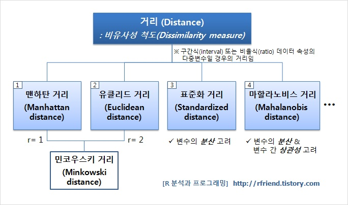

일반적으로 유클리드 거리가 주로 이용되며 공식은 다음과 같다.

$$d_{ij} = \sqrt{\sum_{p=1}^p (x_{ip} - x_{jp})^2}$$

여기서 i,j는 관측치이며 P는 변수 번호이다. 예를 들어 nutrient 데이터를 보면

```r
data(nutrient,package="flexclust")
head(nutrient,4)
```

```
##              energy protein fat calcium iron
## BEEF BRAISED    340      20  28       9  2.6
## HAMBURGER       245      21  17       9  2.7
## BEEF ROAST      420      15  39       7  2.0
## BEEF STEAK      375      19  32       9  2.6
```

첫 두 데이타(beef braised와 hamburger)사이의 유클리드 거리는 다음과 같이 구할 수 있다.

$$d=\sqrt{(340−245)^2+(20−21)^2+(28−17)^2+(9−9)^2+(2.6−2.7)^2}=95.64$$

R의 dist()함수는 데이타프레임 또는 행렬의 모든 행 사이의 거리를 계산하여 행렬 형식으로 결과를 반환헤 준다.

```r
d=dist(nutrient)
as.matrix(d)[1:4,1:4]
```

```
##              BEEF BRAISED HAMBURGER BEEF ROAST BEEF STEAK
## BEEF BRAISED      0.00000   95.6400   80.93429   35.24202
## HAMBURGER        95.64000    0.0000  176.49218  130.87784
## BEEF ROAST       80.93429  176.4922    0.00000   45.76418
## BEEF STEAK       35.24202  130.8778   45.76418    0.00000
```

관측치 사이의 거리가 크다는 것은 관측치가 유사하지 않다는 것이다. 어떤 관측치와 자신과의 거리는 0이다.

## 계층적 군집분석

모든 관찰치는 자신만의 군집에서 시작하여 유사한 데이타 두 개를 하나의 군집으로 묶는데 이를 모든 데이타가 하나의 군집으로 묶일때까지 반복한다. 알고리즘은 다음과 같다.

```
1. 모든 관찰치를 군집으로 정의한다.
2. 모든 군집에 대하여 다른 모든 군집과의 거리를 계산한다.
3. 가장 작은 거리를 갖는 두 군집을 합해 하나의 군집으로 만든다. 따라서 군집의 갯수가 하나 감소한다.
4. 2와3을 반복하여 모든 관찰치가 하나의  군집으로 합쳐질 때까지 반복한다.
```

2단계에서 군집 사이의 거리를 정의하는 것에 따라 계층적 군집 알고리즘이 달라진다.

가장 많이 쓰이는 다섯가지 방법의 정의는 다음과 같다.

| 군집방법 | 두 군집 사이의 거리 정의 |
| --- | --- |
| single linkage | 한 군집의 점과 다른 군집의 점 사이의 가장 짧은 거리(shortest distance) |
| complete linkage | 한 군집의 점과 다른 군집의 점 사이의 가장 긴 거리(longest distance) |
| average linkage | 한 군집의 점과 다른 군집의 점 사이의 평균 거리. UPGMA(unweighted pair group mean averaging)이라고도 한다. |
| centroid | 두 군집의 centroids(변수 평균의 벡터) 사이의 거리.관측치가 하나인 경우 centroid는 변수의 값이 된다 |
| Ward | 모든 변수들에 대하여 두 군집의 ANOVA sum of square를 더한 값 |

`single linkage clustering`은 긴 시가모양의 군집이 만들어지는 경향이 있으며 이러한 현상을 chaining이라고 한다.

chaining은 유사하지 않은 관측치들의 중간 관측치들이 유사하기 때문에 하나의 군집으로 합쳐지는 것를 말한다.

`complete linkage clustering`은 거의 비슷한 직경을 갖는 compact cluster를 만드는 경향이 있으며 이상치에 민감한 것으로 알려져 있다.

`average linkage clustering`은 두 가지 방법의 타협점이다. chaining결향이 덜하고 이상치에도 덜 민감하다. 또한 분산이 적은 군집을 만드는 경향이 있다.

`Ward`의 방법은 적은 관찰치를 갖는 군집을 만드는 경향이 있으며 관찰치의 수와 거의 같은 군집을 만드는 경향이 있다.

`centroid`방법은 단순하고 이해하기 쉬운 거리의 정의를 갖는 매력적인 방법으로 다른 방법들에 비해 이상치에 덜 민감하지만 average linkage나 Ward방법에 비해 수행능력이 떨어진다.

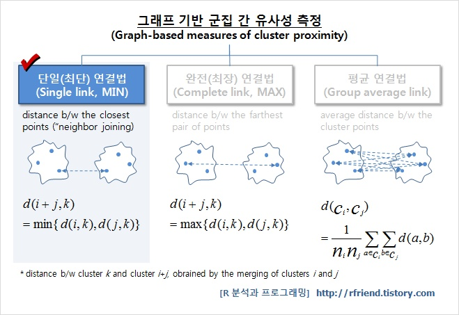

hclust 함수를 이용하면 계층적 군집분석을 쉽게 수행할 수 있다.

```
hclust(d, method=)
```

d는 dist()함수에 의해 만들어지는 거리행렬이고 method로는 “ward.D”, “ward.D2”, “single”, “complete”, “average” (= UPGMA), “mcquitty” (= WPGMA), “median” (= WPGMC) 또는 “centroid” (= UPGMC)를 사용할 수 있다.

### R을 이용한 실습

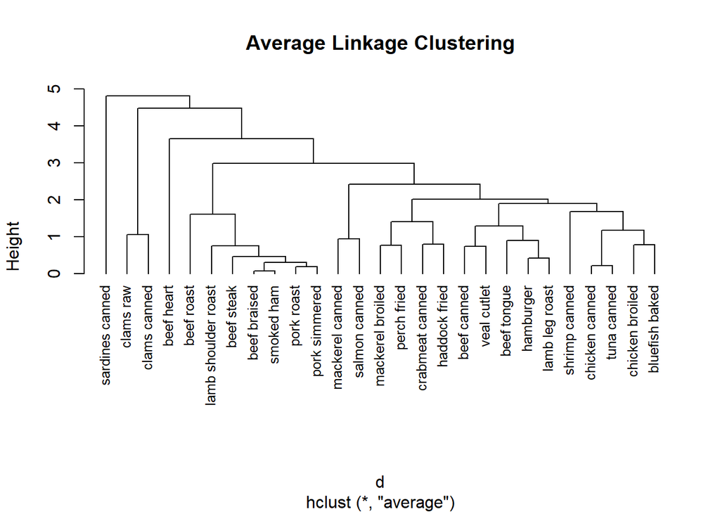

```r
data(nutrient,package="flexclust")
rownames(nutrient)=tolower(rownames(nutrient))
nutrient.scaled=scale(nutrient) #표준화

d=dist(nutrient.scaled)
fit.average=hclust(d, method="average")
plot(fit.average,hang=-1,cex=.8,main="Average Linkage Clustering")
```

### 몇개의 군집으로 나누어야 할까?

NbClust 패키지의 NbClust 함수를 이용해보자.

NbClust 패키지는 군집 수를 결정하기 위한 30개의 지수를 제공하며 군집 수, 거리 측정 및 군집화 방법의 모든 조합을 변화시켜 얻은 다른 결과로부터 최상의 군집화 계획을 사용자에게 제안한다.

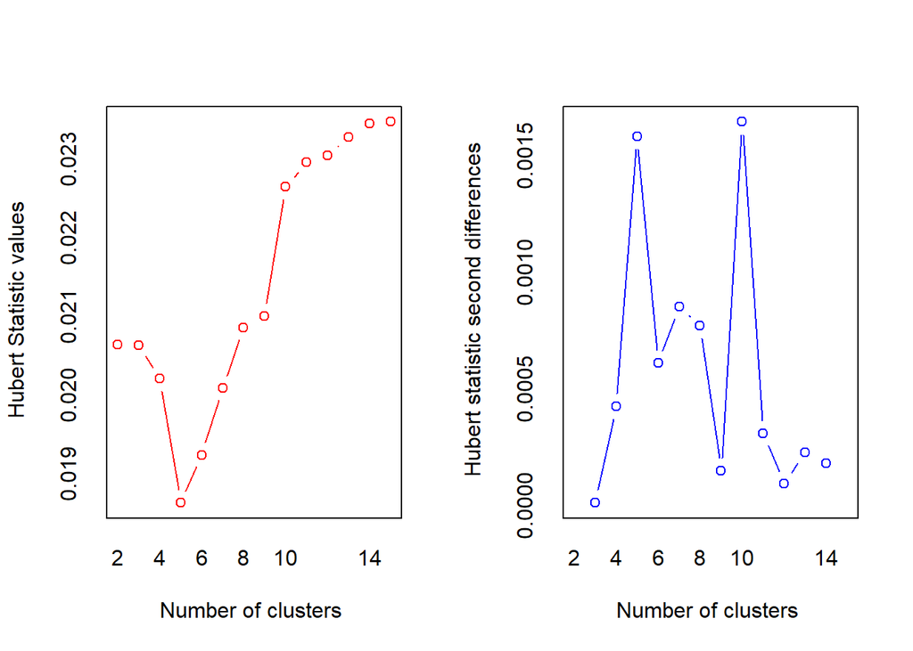

```
## *** : The Hubert index is a graphical method of determining the number of clusters.
##                 In the plot of Hubert index, we seek a significant knee that corresponds to a
##                 significant increase of the value of the measure i.e the significant peak in Hubert
##                 index second differences plot.
##
```

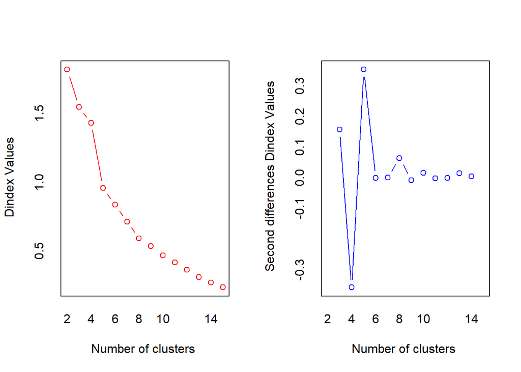

```
## *** : The D index is a graphical method of determining the number of clusters.
##                 In the plot of D index, we seek a significant knee (the significant peak in Dindex
##                 second differences plot) that corresponds to a significant increase of the value of
##                 the measure.
##
## * Among all indices:
## * 4 proposed 2 as the best number of clusters
## * 4 proposed 3 as the best number of clusters
## * 2 proposed 4 as the best number of clusters
## * 4 proposed 5 as the best number of clusters
## * 1 proposed 9 as the best number of clusters
## * 1 proposed 10 as the best number of clusters
## * 2 proposed 13 as the best number of clusters
## * 1 proposed 14 as the best number of clusters
## * 4 proposed 15 as the best number of clusters
##
##                    ***** Conclusion *****
##
## * According to the majority rule, the best number of clusters is  2
##
##
```

```r
library(NbClust)
devAskNewPage(ask=TRUE)
nc=NbClust(nutrient.scaled,distance="euclidean",min.nc=2,max.nc=15,
           method="average")
```

```r
table(nc$Best.n[1,])
```

```
##
##  0  1  2  3  4  5  9 10 13 14 15
##  2  1  4  4  2  4  1  1  2  1  4
```

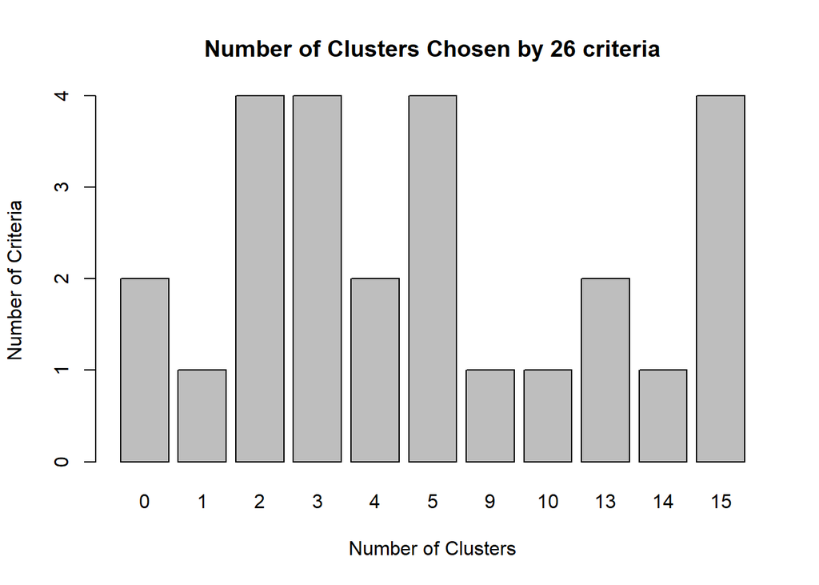

```r
par(mfrow=c(1,1))
barplot(table(nc$Best.n[1,]),xlab="Number of Clusters",ylab="Number of Criteria",
        main="Number of Clusters Chosen by 26 criteria")
```

휴버트 지수 : 휴버트 지수의 유의미한 피크 두 번째 차이 플롯에 해당하는 유의한 무릎을 찾는다.

D 지수 : 측정값의 유의한 증가에 해당하는 유의한 무릎(Dindex 두 번째 차이 그림의 유의한 피크)을 구한다.

### 최종 군집의 수 결정 및 시각화

```r
clusters<-cutree(fit.average,k=5)
table(clusters)
```

```
## clusters
##  1  2  3  4  5
##  7 16  1  2  1
```

```r
aggregate(nutrient,by=list(cluster=clusters),median)
```

```
##   cluster energy protein fat calcium iron
## 1       1  340.0      19  29       9 2.50
## 2       2  170.0      20   8      13 1.45
## 3       3  160.0      26   5      14 5.90
## 4       4   57.5       9   1      78 5.70
## 5       5  180.0      22   9     367 2.50
```

```r
aggregate(as.data.frame(nutrient.scaled),by=list(cluster=clusters),median)
```

```
##   cluster     energy    protein        fat    calcium        iron
## 1       1  1.3101024  0.0000000  1.3785620 -0.4480464  0.08110456
## 2       2 -0.3696099  0.2352002 -0.4869384 -0.3967868 -0.63743114
## 3       3 -0.4684165  1.6464016 -0.7534384 -0.3839719  2.40779157
## 4       4 -1.4811842 -2.3520023 -1.1087718  0.4361807  2.27092763
## 5       5 -0.2708033  0.7056007 -0.3981050  4.1396825  0.08110456
```

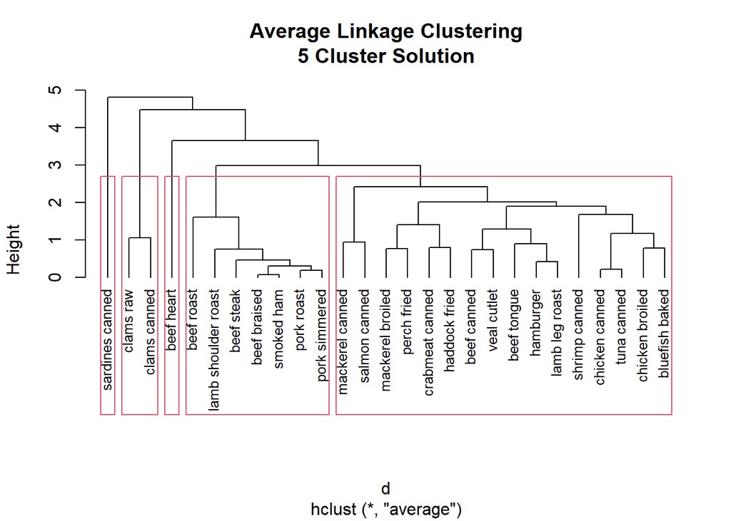

```r
plot(fit.average,hang=-1,cex=.8,
     main="Average Linkage Clustering\n5 Cluster Solution")
rect.hclust(fit.average,k=5)
```

분할군집에서는 먼저 군집의 갯수 K 를 정한 후 데이타를 무작위로 K개의 군으로 배정한 후 다시 계산하여 군집으로 나눈다.

### K-means clustering

k-means 알고리즘

분할 군집에서 가장 많이 사용되는 방법은 k-means clustering이다. 알고리즘은 다음과 같다.

```
1. K개의 centroids를 선택한다.(K개의 행을 무작위로 선택)
2. 각 데이타를 가장 가까운 centroid에 할당한다.
3. 각 군집에 속한 모든 데이타의 평균으로 centroid를 다시 계산한다.(즉, centroid는 p-개의 길이를 갖는 평균벡터로 p는 변수의 수이다.)
4. 각 데이타를 가장 가까운 centroid에 할당한다.
5. 모든 관측치의 재할당이 일어나지 않거나 최대반복횟수(R에서의 dafault값은 10회)에 도달할 때까지 3과 4를 반복한다.
```

#### k-means의 장단점

k-means는 계층적 군집분석에 비해 큰 데이타셋에서 사용할 수 있으며 관측치가 군집에 영구히 할당되는 것이 아니라 최종결과를 개선시키는 방향으로 이동한다. 하지만 평균을 사용하기 때문에 연속형변수에만 적용될 수 있으며 이상치에 심하게 영향을 받는다. 또한 non-convex형태의(예를 들어 U모양) 군집이 있는 경우 잘 수행되지 않는다.

#### R을 이용한 실습

- 데이터 준비

training 데이터로 모델(70%)을 만들고, testing 데이터로 모델(30%)을 평가 하기 위한 사전 작업입니다.

```r
library(caret)
set.seed(1712)

inTrain <- sample(1:nrow(iris), nrow(iris)*0.7)
training <- iris[inTrain,]
testing <- iris[-inTrain,]
c(nrow(training),nrow(testing))
```

```
## [1] 105  45
```

- 표준화

K-means 군집 분석은 관측치 간의 거리를 이용하기 때문에 변수의 단위가 결과에 큰 영향을 미칩니다. 그래서 변수를 표준화 하는 작업이 필요합니다.

scale 함수를 사용해서 표준화를 합니다.

```r
training.data <- scale(training[-5])
summary(training.data)
```

```
##   Sepal.Length       Sepal.Width        Petal.Length      Petal.Width
##  Min.   :-1.65379   Min.   :-2.58395   Min.   :-1.4414   Min.   :-1.3223
##  1st Qu.:-0.85357   1st Qu.:-0.71924   1st Qu.:-1.1738   1st Qu.:-1.2002
##  Median :-0.05335   Median :-0.01998   Median : 0.2712   Median : 0.1430
##  Mean   : 0.00000   Mean   : 0.00000   Mean   : 0.0000   Mean   : 0.0000
##  3rd Qu.: 0.74687   3rd Qu.: 0.67928   3rd Qu.: 0.8063   3rd Qu.: 0.8757
##  Max.   : 2.34731   Max.   : 2.54399   Max.   : 1.6091   Max.   : 1.6083
```

- 군집분석 수행

k를 3으로 설정하여 3개의 시작점을 기준으로 3개의 군집을 생성하겠습니다.

```r
iris.kmeans <- kmeans(training.data[,-5], centers = 3, iter.max = 10000)
iris.kmeans$centers
```

```
##   Sepal.Length Sepal.Width Petal.Length Petal.Width
## 1    1.1451374   0.1454383    1.0272883   1.0568889
## 2   -0.9936058   0.7142480   -1.1911900  -1.1604704
## 3    0.1248522  -0.9728972    0.4647548   0.4016253
```

- 군집분석 결과 확인

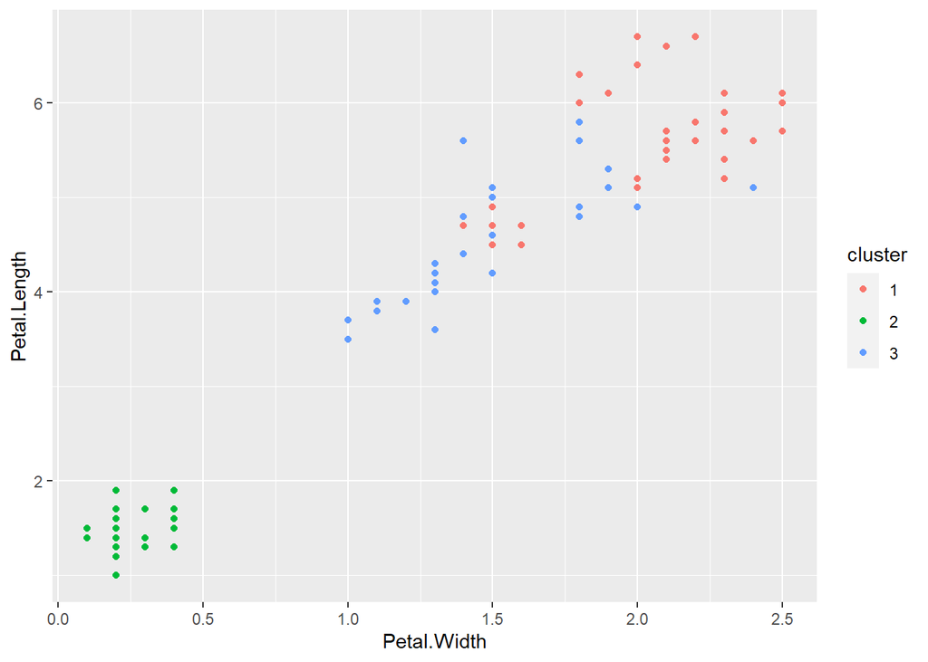

```r
training$cluster <- as.factor(iris.kmeans$cluster)
qplot(Petal.Width, Petal.Length, colour = cluster, data = training)
```

```r
table(training$Species, training$cluster)
```

```
##
##               1  2  3
##   setosa      0 40  0
##   versicolor  6  0 20
##   virginica  25  0 14
```

> 군집분석은 실제 집단의 참값을 알 수 없는 비지도 방법입니다.
- 군집의 수 결정

군집분석에서는 입력하는 변수와 함께 군집의 수 결정이 중요합니다.

몇개의 군집 중심이 적당한지 결정하는 방법에는 여러가지가 있습니다.

그중 자주 사용하는 NbClust 패키지를 사용하는 방법과 군집 내 sum of squares를 사용하는 방법이 있습니다.

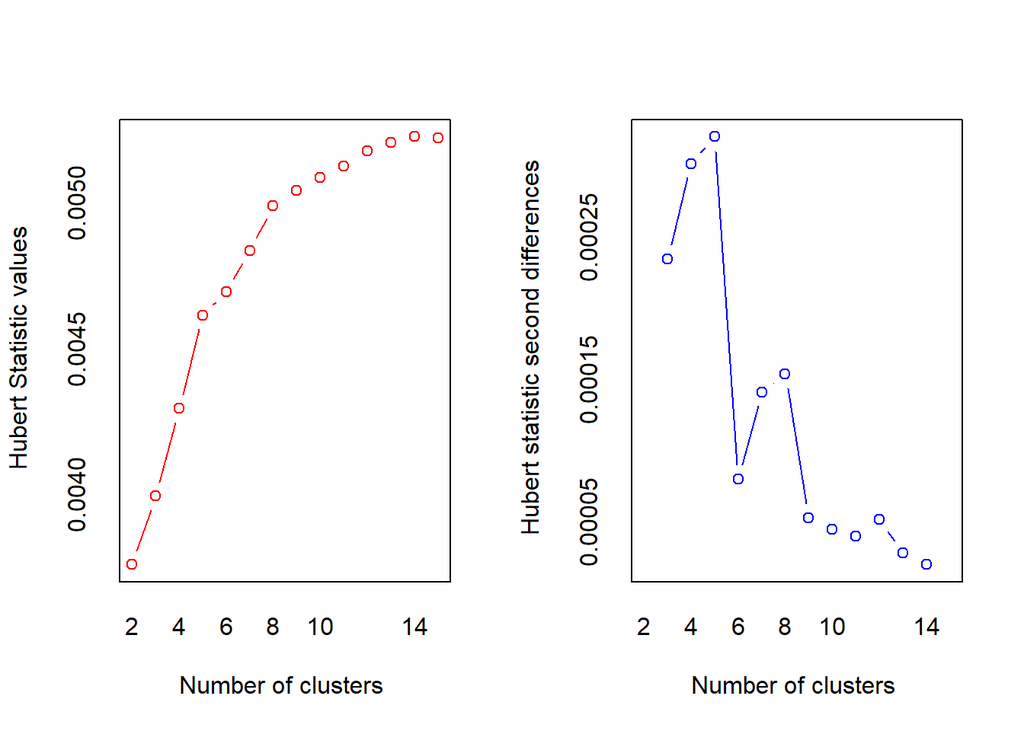

```
## *** : The Hubert index is a graphical method of determining the number of clusters.
##                 In the plot of Hubert index, we seek a significant knee that corresponds to a
##                 significant increase of the value of the measure i.e the significant peak in Hubert
##                 index second differences plot.
##
```

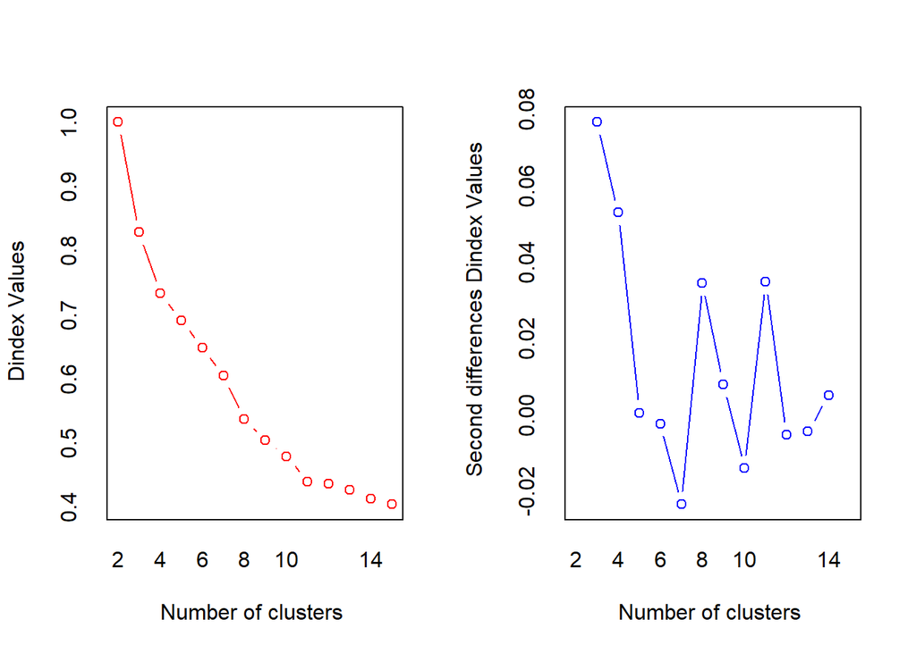

```
## *** : The D index is a graphical method of determining the number of clusters.
##                 In the plot of D index, we seek a significant knee (the significant peak in Dindex
##                 second differences plot) that corresponds to a significant increase of the value of
##                 the measure.
##
## * Among all indices:
## * 7 proposed 2 as the best number of clusters
## * 5 proposed 3 as the best number of clusters
## * 4 proposed 4 as the best number of clusters
## * 1 proposed 6 as the best number of clusters
## * 3 proposed 9 as the best number of clusters
## * 3 proposed 11 as the best number of clusters
## * 1 proposed 15 as the best number of clusters
##
##                    ***** Conclusion *****
##
## * According to the majority rule, the best number of clusters is  2
##
##
```

```r
nc <- NbClust(training.data, min.nc = 2, max.nc = 15, method = "kmeans")
```

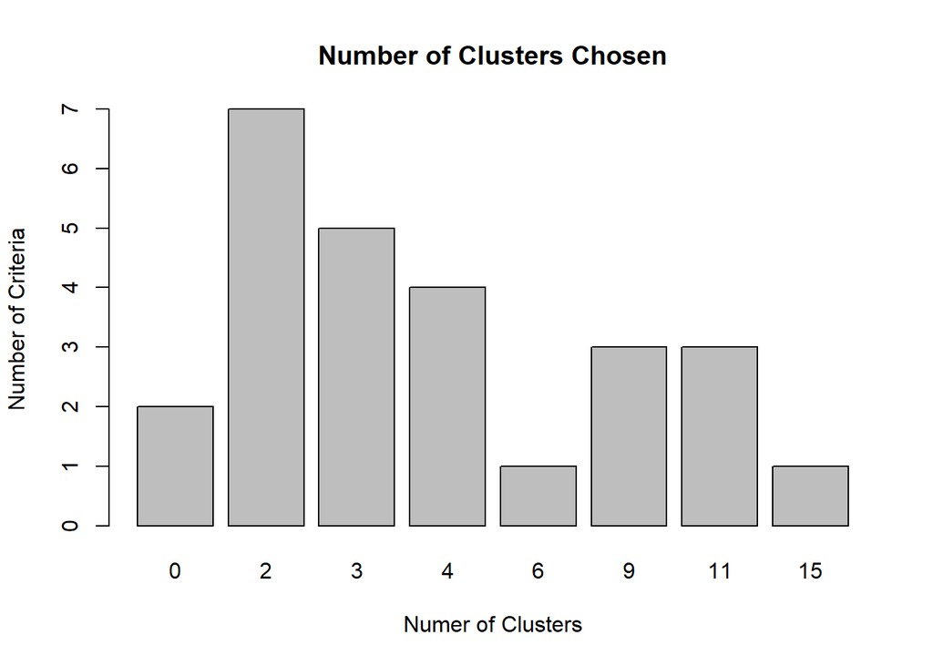

```r
par(mfrow=c(1,1))
barplot(table(nc$Best.n[1,]),
        xlab="Numer of Clusters", ylab="Number of Criteria",
        main="Number of Clusters Chosen")
```

이번에는 Sum of square means를 보겠습니다.

결론적으로 iris 데이터는 3개의 군집으로 구분하는 것이 좋습니다.

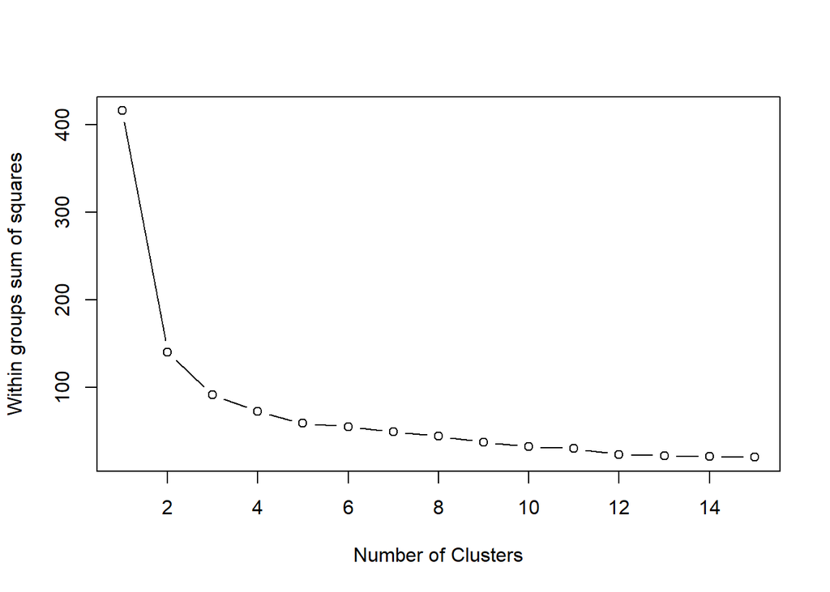

```r
wssplot <- function(data, nc = 15, seed = 1234) {
  wss <- (nrow(data) - 1) * sum(apply(data, 2, var))
  for (i in 2:nc) {
    set.seed(seed)
    wss[i] <- sum(kmeans(data, centers=i)$withinss)}
  plot(1:nc, wss, type="b", xlab = "Number of Clusters",
       ylab = "Within groups sum of squares")}

wssplot(training.data)
```

군집분석 결과와 기존에 저장된 종과 비교해보겠습니다.

```r
table(training$cluster,training$Species)
```

```
##
##     setosa versicolor virginica
##   1      0          6        25
##   2     40          0         0
##   3      0         20        14
```

Adjusted Rand Index는 Species과 cluster의 일치 정도를 정량화하는데 사용할 수 있다.

-1은 전혀 일치하지 않는 것이고 1은 완벽하게 일치하는 것이다.

```r
library(flexclust)
randIndex(table(training$cluster,training$Species))
```

```
##       ARI
## 0.6297515
```

### Model-based clustering (Gaussian Mixture Model)

확률분포에 대한 정보가 있을 경우 이를 활용하여 군집분석

k번째 군집에 속한 관측치 x 가 다변량 정규분포인 확률밀도함수 f 를 가진다고 가정

각 객체각 각 군집에 속할 사후 확률을 계산하여 가장 확률이 높은 군집으로 할당

모형선택방법 중 BIC (Bayesian information criterion)를 사용하여 이 값이 최대가 되는 모형을 선택

모든 모형에 대해 계산을 한 후 BIC를 기준으로 모형을 선택한다.

EM 알고리즘은, 먼저 각각의 데이터가 어느 클러스터에 속할지에 대한 정보를 update해 expectation을 계산하고,

다음으로 업데이트 된 정보들을 사용해 나머지 값들로 가장 log likelihood를 최대화하는 parameter들을 (μ,Σ,π를) 찾아낸다.

알고리즘을 돌리면 아래처럼 iteration이 지날 때 마다 점점 좋은 값을 찾아준다.

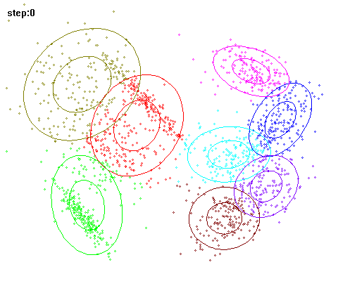

K-means는 평균 거리 중심으로 중심을 이동하면서 군집화를 수행하는 방식이기 때문에 개별 군집 내의 데이터가 원형으로 흩어져 있는 경우에 매우 효과적으로 군집화가 수행될 수 있다. 반면 GMM은 타원형으로 길게 늘어진 데이터 군집화에 보다 효과적으로 적용된다.

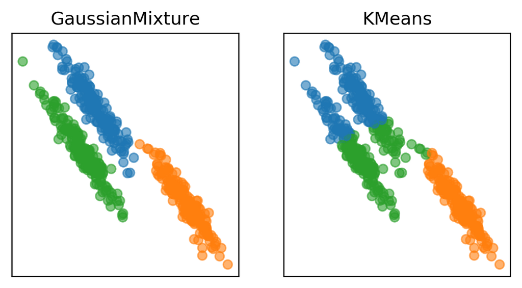

```r
library(mclust)
mc = Mclust(wine[-1])
summary(mc)
```

```
## ----------------------------------------------------
## Gaussian finite mixture model fitted by EM algorithm
## ----------------------------------------------------
##
## Mclust VVE (ellipsoidal, equal orientation) model with 3 components:
##
##  log-likelihood   n  df       BIC       ICL
##       -3015.333 178 158 -6849.387 -6850.694
##
## Clustering table:
##  1  2  3
## 59 69 50
```

```r
mb.clust = table(wine$Type, mc$classification)
mb.clust
```

```
##
##      1  2  3
##   1 59  0  0
##   2  0 69  2
##   3  0  0 48
```

```r
randIndex(mb.clust)
```

```
##       ARI
## 0.9667411
```

### DBSCAN

밀도기반 군집분석(DBSCAN) 이란?

데이터의 위치 정보를 사용하여 군집 생성

밀도기반의 의미? 점들이 밀집된 곳을 하나의 군집으로 보는 것

노이즈 (아무 군집에도 들어가지 않는 데이터, 필요없는 값)을 제외시킴

주요 파라미터

ε- 거리(eps): 하나의 개체를 중심으로 eps 거리 내 몇개의 점이 있는지 파악. 이 숫자가 정해진 밀도보다 크다면 하나의 군집을 이루게 됨. 만약 없으면 pass

최소 점의 수 (Minimum Points): 군집을 이루기 위한 최소한의 개체 수. 최소 몇개 점이 있어야 군집을 만들 수 있는가?

프로세스

step1 : 한 점을 중심으로 ε- 거리 내 이웃 점들 중 이웃의 수가 최소 점 이상인지 확인, 있으면 이웃점들을 포함한 군집을 생성하고, 없다면 가장 가까운 이웃 점으로 이동.

step2 : 이동한 점을 기준으로 step1 실행. ε- 거리 내 임계점보다 많은 이웃이 있고 중심이 기존 군집에 속해 있으면 기존 군집에 이웃 추가. 만약 중심이 군집에 속하지 않았으면 새로운 군집이 생성되고 다음 이웃점으로 이동.

step3 : 모든 비중심이 되는 점들은 ε- 거리 내 군집에 할당. 할당되지 않은 점은 노이즈로 구분됨.

프로세스 예시

ε : 3cm / Min points : 4개 일때

1. step1 : 1번 점을 중심으로 3cm 거리 안에 점이 4개인지 판단. –> 이웃 점이 3개 이므로 PASS! –> 중심이 가장 가까운 이웃점인 3번으로 이동.

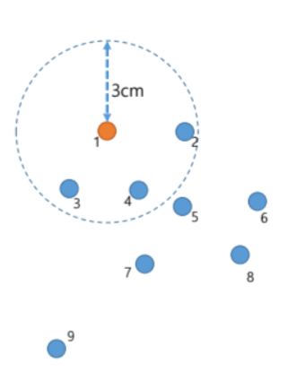

2. step2 : 3번 점을 중심으로3cm 거리 안에 점이 4개 이상 인지 판단 –> 2개이므로 PASS! –> 4번 점으로 이동.

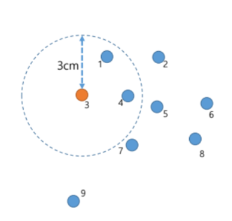

3. step3 : 4번 점을 중심으로 3cm 거리 안에 점이 4개 이상인지 판단 –> 5개 이므로 1군집이 생성!! (1, 2, 3, 4, 5, 7)

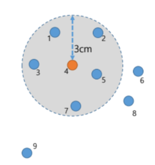

1군집 (1, 2, 3, 4, 5, 7)

4. step4 : 2번 점을 중심으로 3cm 거리 안에 점이 4개 이상인지 판단 –> 3개이므로 PASS

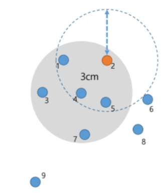

1군집 (1, 2, 3, 4, 5, 7)

5. step5 : 5번 점을 중심으로 3cm 거리 안에 점이 4개 이상인지 판단 –> 5개 –> 5번 중심이 속한 군집에 6, 8번 점이 포함됨

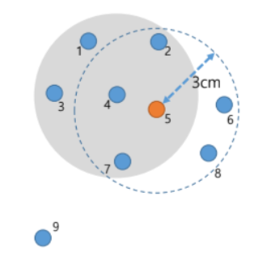

1군집 (1, 2, 3, 4, 5, 7, 6, 8)

6. step6: 7번 점을 중심으로 3cm 거리 안에 점이 4개 이상인지 판단 –> 2개 이므로 PASS

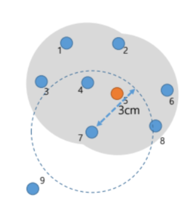

1군집 (1, 2, 3, 4, 5, 7, 6, 8)

7. step7: 6번 점을 중심으로 3cm 거리 안에 최소 점이 4개인지 판단 –> 2개 이므로 PASS

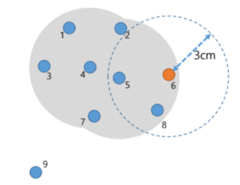

8. step8: 8번 점을 중심으로 3cm 안에 최소 점이 4개인지 판단 –> 2개 이므로 PASS
9. step9: 9번 점을 중심으로 3cm 거리 안에 최소 점이 4개 인지 판단 –> 0개 이므로 PASS –> 9번은 이상치!

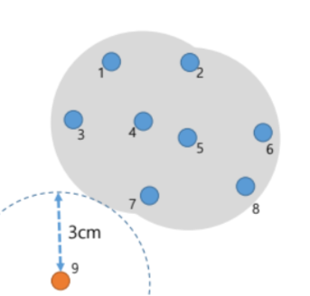

1군집 (1, 2, 3, 4, 5, 7, 6, 8), 이상치 9

#### DBSCAN 장단점은?

장점

다양한 기하학적 형태의 군집 유형을 구분해 낼 수 있음.

군집의 개수를 자동으로 찾아줌

노이즈를 구분하여 버림으로 의미없는 군집 생성을 차단함 (이상치를 구분해내기 위해서 활용하기도 함)

계산량이 적어서 빠름

단점

데이터의 밀도가 다양한 데이터에 적합하지 않음. (어떤 군집은 밀도가 듬성듬성한데, 어떤 군집은 오밀조밀 할 때)

ε- 거리를 추정하기 어려움 (Nbclust과 같은 패키지가 적용되지 않음)

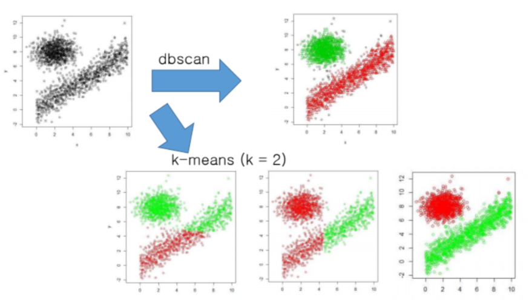

```r
library(factoextra)
```

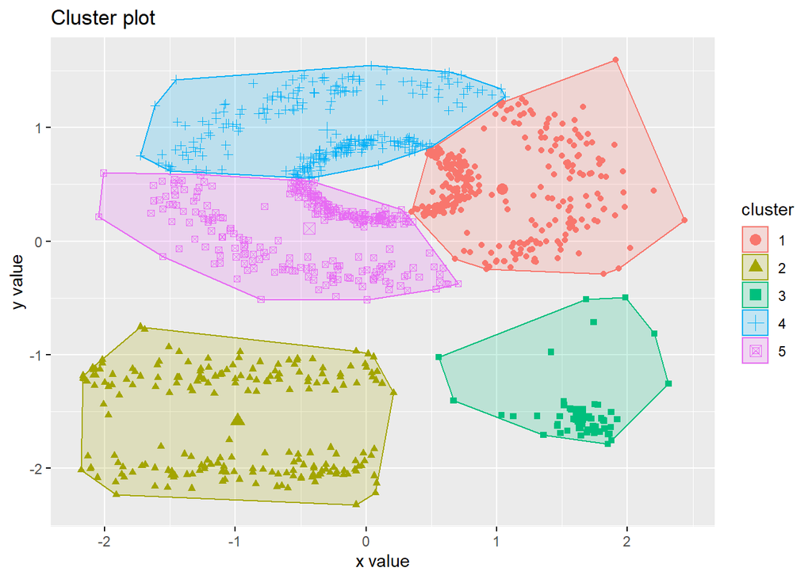

```r
data("multishapes")
df <- multishapes[, 1:2]
set.seed(123)
km.res <- kmeans(df, 5, nstart = 25)
fviz_cluster(km.res, df, frame = FALSE, geom = "point")
```

```r
library(fpc)
library(dbscan)
```

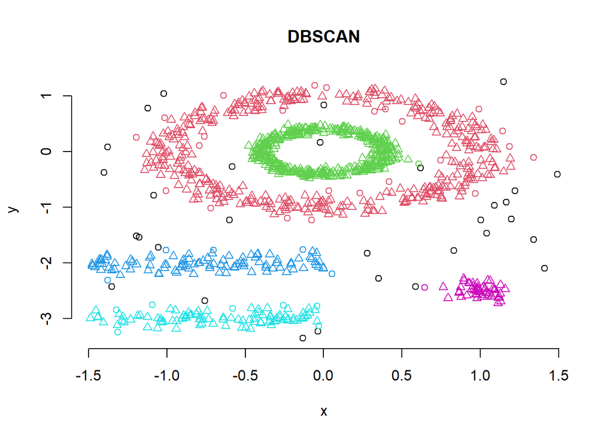

```r
data("multishapes", package = "factoextra")
df <- multishapes[, 1:2]

# Compute DBSCAN using fpc package
set.seed(123)
db <- fpc::dbscan(df, eps = 0.15, MinPts = 5)
# Plot DBSCAN results
plot(db, df, main = "DBSCAN", frame = FALSE)
```

Method for determining the optimal eps value

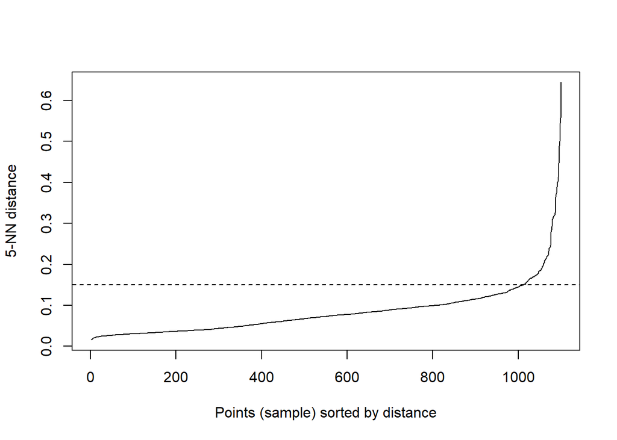

```r
dbscan::kNNdistplot(df, k =  5)
abline(h = 0.15, lty = 2)
```

## clustering 해보기

The wine dataset contains the results of a chemical analysis of wines grown in a specific area of Italy. Three types of wine are represented in the 178 samples, with the results of 13 chemical analyses recorded for each sample. The Type variable has been transformed into a categoric variable.

```r
data(wine,package="rattle")
head(wine)
```

```
##   Type Alcohol Malic  Ash Alcalinity Magnesium Phenols Flavanoids Nonflavanoids
## 1    1   14.23  1.71 2.43       15.6       127    2.80       3.06          0.28
## 2    1   13.20  1.78 2.14       11.2       100    2.65       2.76          0.26
## 3    1   13.16  2.36 2.67       18.6       101    2.80       3.24          0.30
## 4    1   14.37  1.95 2.50       16.8       113    3.85       3.49          0.24
## 5    1   13.24  2.59 2.87       21.0       118    2.80       2.69          0.39
## 6    1   14.20  1.76 2.45       15.2       112    3.27       3.39          0.34
##   Proanthocyanins Color  Hue Dilution Proline
## 1            2.29  5.64 1.04     3.92    1065
## 2            1.28  4.38 1.05     3.40    1050
## 3            2.81  5.68 1.03     3.17    1185
## 4            2.18  7.80 0.86     3.45    1480
## 5            1.82  4.32 1.04     2.93     735
## 6            1.97  6.75 1.05     2.85    1450
```

첫번째 Type을 제외한 나머지 독립변수들을 사용하여 k-means 군집분석을 수행해보고 결과를 평가해보세요.

```r
df=scale(wine[-1])
nc=NbClust(df,min.nc=2,max.nc=15,method="kmeans")
table(nc$Best.n[1,])
par(mfrow=c(1,1))
barplot(table(nc$Best.n[1,]),xlab="Number of Clusters",ylab="Number of Criteria",
        main="Number of Clusters Chosen by 26 criteria")
wssplot(df)
fit.km=kmeans(df,3)
fit.km$cluster
fit.km$size
fit.km$centers
ct.km<-table(wine$Type,fit.km$cluster)
ct.km
randIndex(ct.km)
```